# Práctica01_NBA

Beatriz Cárdaba

28/10/2020

# Modelo predictivo de los Salarios NBA

### Modelo a partir de las relaciones entre el salario y las caraterísticas del jugador.

Para la creación del modelo disponemos de la base de datos nba_data, importamos los datos en el formato deseado e importamos las liberías que se vayan a utilizar:

### Características del Dataset

Es importante conocer las dimensiones de las caraterísticas y variables de los datos disponibles importados.

```
## 'data.frame':    485 obs. of  28 variables:
##  $ Player         : chr  "Zhou Qi" "Zaza Pachulia" "Zach Randolph" "Zach LaVine" ...
##  $ Salary         : int  815615 3477600 12307692 3202217 3057240 1312611 74159 46080 12016854 1435750 ...
##  $ NBA_Country    : chr  "China" "Georgia" "USA" "USA" ...
##  $ NBA_DraftNumber: int  43 42 19 13 10 62 62 62 23 35 ...
##  $ Age            : int  22 33 36 22 20 24 30 23 30 23 ...
##  $ Tm             : chr  "HOU" "GSW" "SAC" "CHI" ...
##  $ G              : int  16 66 59 24 62 79 2 5 70 45 ...
##  $ MP             : int  87 937 1508 656 979 2238 7 118 2200 430 ...
##  $ PER            : num  0.6 16.8 17.3 14.6 8.2 11.5 -4.9 0.9 11.1 20.6 ...
##  $ TS.            : num  0.303 0.608 0.529 0.499 0.487 0.543 0 0.315 0.543 0.592 ...
##  $ X3PAr          : num  0.593 0.004 0.193 0.346 0.387 0.489 0.667 0.333 0.39 0.075 ...
##  $ FTr            : num  0.37 0.337 0.14 0.301 0.146 0.141 0 0.214 0.186 0.555 ...
##  $ ORB.           : num  6.5 11 7 1.4 4.9 1.3 15.9 0 5 13.6 ...
##  $ DRB.           : num  16.8 25 23.8 14.4 18.3 11.3 15.4 5 14 25.2 ...
##  $ TRB.           : num  11.7 18.5 15 7.7 11.7 6.1 15.7 2.5 9.5 19.3 ...
##  $ AST.           : num  1.5 15.4 14.9 18.6 7.3 13.3 0 23.2 9.7 11 ...
##  $ STL.           : num  1.1 1.9 1.4 1.8 0.8 1.4 7.2 2.6 0.9 1.8 ...
##  $ BLK.           : num  6.8 1.3 0.6 0.5 2.5 0.3 0 2.4 1.4 2.8 ...
##  $ TOV.           : num  18.2 19.3 12.5 9.7 15.6 9.1 0 19.3 12 15.4 ...
##  $ USG.           : num  19.5 17.2 27.6 29.5 15.5 17 19.2 21.7 14.6 21.7 ...
##  $ OWS            : num  -0.4 1.7 0.3 -0.1 -0.4 1.6 -0.1 -0.5 2 0.8 ...
##  $ DWS            : num  0.1 1.4 1.1 0.5 1.2 1.6 0 0.1 1 0.6 ...
##  $ WS             : num  -0.2 3.1 1.4 0.4 0.8 3.1 0 -0.4 3.1 1.4 ...
##  $ WS.48          : num  -0.121 0.16 0.046 0.027 0.038 0.067 -0.251 -0.169 0.067 0.156 ...
##  $ OBPM           : num  -10.6 -0.6 -0.6 -0.7 -3.7 -0.4 -12.6 -8.7 -0.4 -0.1 ...
##  $ DBPM           : num  0.5 1.3 -1.3 -2 0.9 -0.5 -0.7 -1.9 -0.6 0.6 ...
##  $ BPM            : num  -10.1 0.8 -1.9 -2.6 -2.9 -0.9 -13.3 -10.6 -1 0.5 ...
##  $ VORP           : num  -0.2 0.7 0 -0.1 -0.2 0.6 0 -0.3 0.5 0.3 ...
```

Se define el significado de cada una de las variables del modelo

### Diccionario de datos:

- Player: nombre del jugados
- Salary: salario del jugadore en $
- NBA_Country: país de nacionalidad del jugador
- NBA_DraftNumber: posición en el Draft del jugador
- Age: edad del jugador
- Tm: equipo del jugador
- G: partidos que ha disputado el jugador
- MP: minutos que ha jugado el jugador
- PER: valoración del jugador por minuto, estandarizado sabiendo que la media de la liga es 15.
- TS.: porcentaje total de acierto en tiro. Tiendo en cuenta tiros de 2, de 3 y tiros libres.
- X3PAr: porcentaje en tiros de 3
- FTr: porcentaje en tiros libres
- ORB.: porcentaje de los rebotes ofensivos que ha cogido del total que se han producido mientras estaba en campo
- DRB.: porcentaje de los rebotes defensivos que ha cogido del total que se han producido mientras estaba en campo
- TRB.: porcentaje de los rebotes totales que ha cogido del total que se han producido mientras estaba en campo
- AST.: porcentaje de las asistencias totales que ha realizado del total que se han producido mientras estaba en campo
- STL.: porcentaje de los robos totales que ha realizado del total que se han producido mientras estaba en campo
- BLK.: porcentaje de los bloqueos rebdef totales que ha realizado del total que se han producido mientras estaba en campo
- TOV.: perdidas de la posesion respocto a 100 jugadas
- USG.: porcentaje de jugadas que interviene al jugador respecto del total de las que se realizan mientras está en campo
- OWS: Responsabilida ofensiva del jugador en las victorias.
- DWS: Responsabilida ofensiva del jugador en las victorias.
- WS: responsabilidad de un jugador en las victorias
- WS.48: media de la responsabilidad de las vuictorias en los 48 que dura el partido.
- OBPM: Calcula el más/menos de un jugador en ataque respecto al rendimiento del equipo por cada 100 posesiones.
- DBPM: Calcula el más/menos de un jugador en defensa respecto al rendimiento del equipo por cada 100 defensas.
- BPM: Calcula el más/menos de un jugador respecto al rendimiento del equipo por cada 100 posesiones.
- VORP: indica el impacto del jugador en comparación al impacto por cada 100 posesiones del equipo cuando es reemplazado a lo largo de 82 partidos.

Observando el tipo de variables y la definición se puede diferenciar en tres variables categóricas: player , country y Tm, y 25 variables numéricas. Para estudiar las correlaciones entre el salario de cada jugador y el resto de caraterísticas vamos a tener en cuenta las variables numéricas.

Dadas estas caraterísticas , el numero de variables y la predicción propuesta, hay que realizar una regresión múltiple que explique las correlaciones entre la variable dependiente, el salario, y las variables explicativas, las caraterísticas de cada jugador. En este caso seleccionaremos aquellas numéricas.

### Diagramas de dispersión

Un buen primer paso en la regresión múltiple es examinar las relaciones entre las variables explicativas y la explicada mediante gráficos de dispersión:

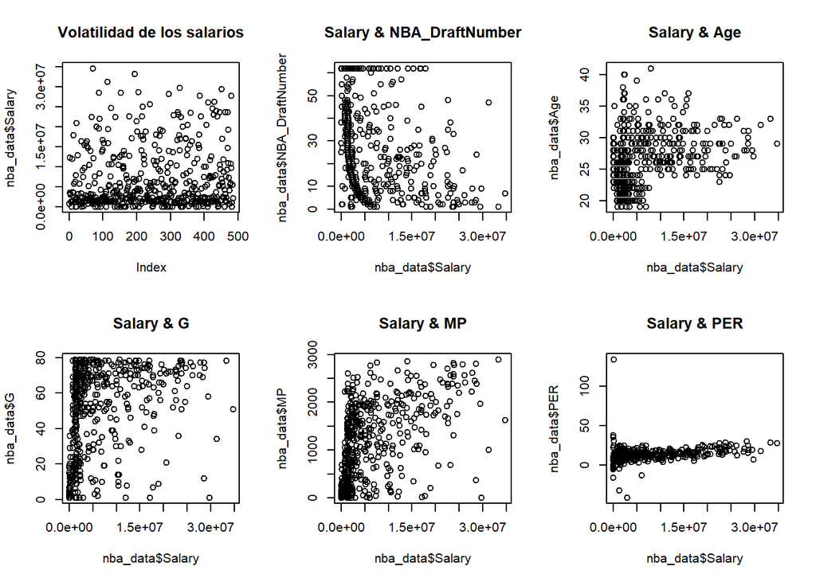

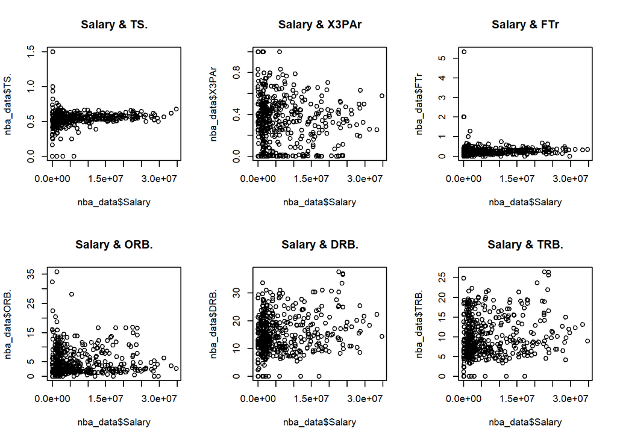

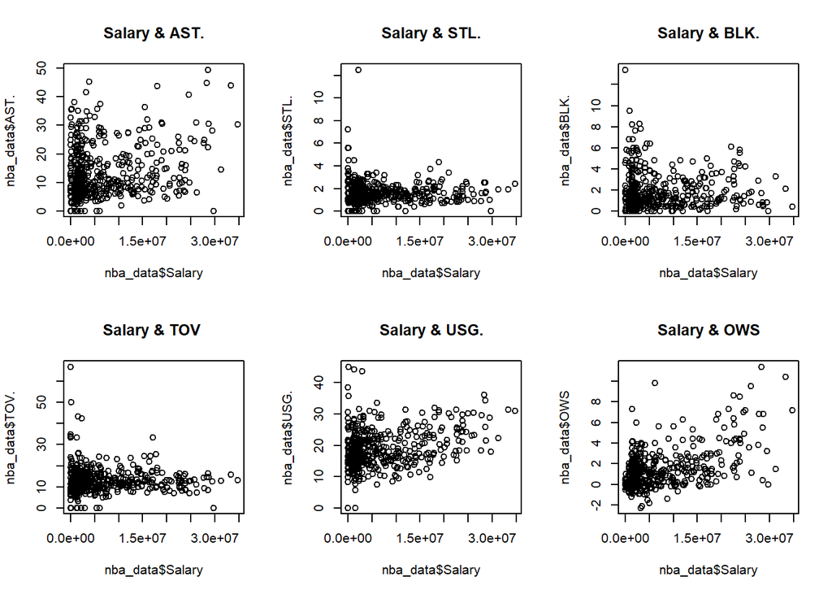

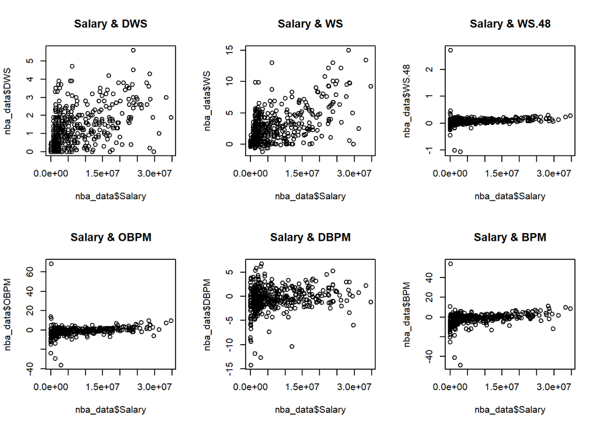

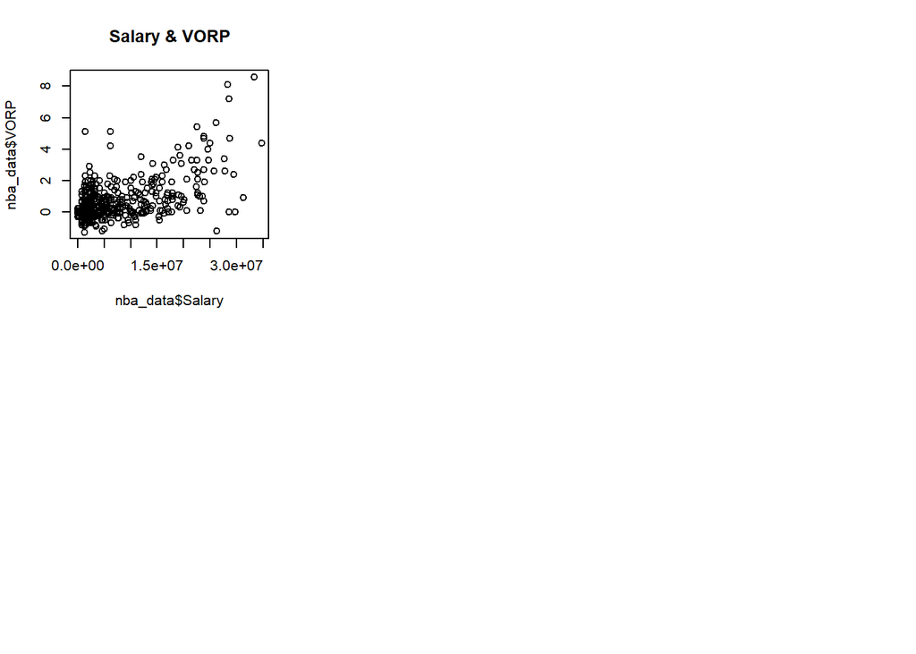

Mediante estos gráficos se pueden ver las relaciones entre las variables explicativas y la explicada. Podemos ver la distribución de los datos para valor de salario y en que parte se agrupan mayoritariamente cada variable. También se pueden ver los outliers de cada variable.

### Regresión lineal multiple

Hacemos una regresión lineal múltiple para conocer los coefcientes de correlación de cada variable respecto del salario. Esta primera regresión llamada “regres_nba”, contine todas las variables numéricas y todas las observaciones de la muestra.

```
##
## Call:
## lm(formula = Salary ~ . - Player - NBA_Country - Tm, data = nba_data)
##
## Residuals:
##       Min        1Q    Median        3Q       Max
## -15344434  -2975002   -390994   2102049  21682686
##
## Coefficients:
##                 Estimate Std. Error t value Pr(>|t|)
## (Intercept)     -2250339    4899140  -0.459    0.646
## NBA_DraftNumber   -60481      12755  -4.742 2.83e-06 ***
## Age               516821      56511   9.146  < 2e-16 ***
## G                -154411      24983  -6.181 1.41e-09 ***
## MP                  5657       1083   5.224 2.67e-07 ***
## PER              -355059     280566  -1.266    0.206
## TS.             -2162767    5149052  -0.420    0.675
## X3PAr           -3458209    2357905  -1.467    0.143
## FTr              -158470     886960  -0.179    0.858
## ORB.            -1055234     902929  -1.169    0.243
## DRB.             -855005     893502  -0.957    0.339
## TRB.             2006676    1788697   1.122    0.263
## AST.              -19606      47542  -0.412    0.680
## STL.             -196551     421995  -0.466    0.642
## BLK.              110238     318223   0.346    0.729
## TOV.                4208      52692   0.080    0.936
## USG.              169431     104692   1.618    0.106
## OWS             -1271685    4493110  -0.283    0.777
## DWS             -1735775    4518854  -0.384    0.701
## WS               1827796    4498896   0.406    0.685
## WS.48            1914677   11797052   0.162    0.871
## OBPM             1878971    4744860   0.396    0.692
## DBPM             1438902    4660878   0.309    0.758
## BPM             -1295954    4678340  -0.277    0.782
## VORP              629465     633799   0.993    0.321
## ---
## Signif. codes:  0 '***' 0.001 '**' 0.01 '*' 0.05 '.' 0.1 ' ' 1
##
## Residual standard error: 5103000 on 458 degrees of freedom
##   (2 observations deleted due to missingness)
## Multiple R-squared:  0.5479, Adjusted R-squared:  0.5242
## F-statistic: 23.13 on 24 and 458 DF,  p-value: < 2.2e-16
```

Estos datos nos permiten interpretar los coeficientes de correlación. Por ejemplo, por cada descenso de una posición en el draft cada jugador cobrará un probmedio de 60481$ menos al año.

Las únicas variables significativas para un α = 0.05 son el número de draft, la edad, el número de partidos realizados y los minutos jugados. Aunque la significación no tiene por qué estar relacionada con las variables que utilizaremos para el modelo predictivo.

### Intervalos de confianza para las variables.

Estos datos muestran con una probabilidad del 95% en que rango se situan cada uno de los coeficientes de las variables de la regresión anterior.

```
##                         2.5 %       97.5 %
## (Intercept)     -11877918.330  7377239.702
## NBA_DraftNumber    -85546.335   -35416.532
## Age                405767.930   627873.452
## G                 -203505.950  -105315.804
## MP                   3528.691     7784.595
## PER               -906415.318   196296.479
## TS.             -12281462.432  7955929.041
## X3PAr            -8091862.183  1175444.570
## FTr              -1901486.160  1584545.305
## ORB.             -2829631.828   719163.263
## DRB.             -2610875.994   900865.980
## TRB.             -1508395.369  5521746.905
## AST.              -113033.059    73820.611
## STL.             -1025837.515   632734.620
## BLK.              -515120.100   735595.442
## TOV.               -99340.564   107757.190
## USG.               -36306.351   375167.639
## OWS             -10101352.638  7557982.301
## DWS             -10616033.934  7144483.108
## WS               -7013240.699 10668833.056
## WS.48           -21268384.080 25097737.469
## OBPM             -7445424.606 11203367.479
## DBPM             -7720455.830 10598258.822
## BPM             -10489626.506  7897718.508
## VORP              -616048.321  1874979.191
```

Por ejemplo, para la variable draft, con una confianza del 95% la variacion de sueldo por cada descenso en un puesto en el draft el sueldo disminurá entre 85546.335$ y 35416.532$.

## Análisis de residuos

### Normalidad

Representamos graficamente mediante QQplot la normalidad de los datos. Ayuda a seber si la distribución de los datos de la muestra siguen una distribución específica.

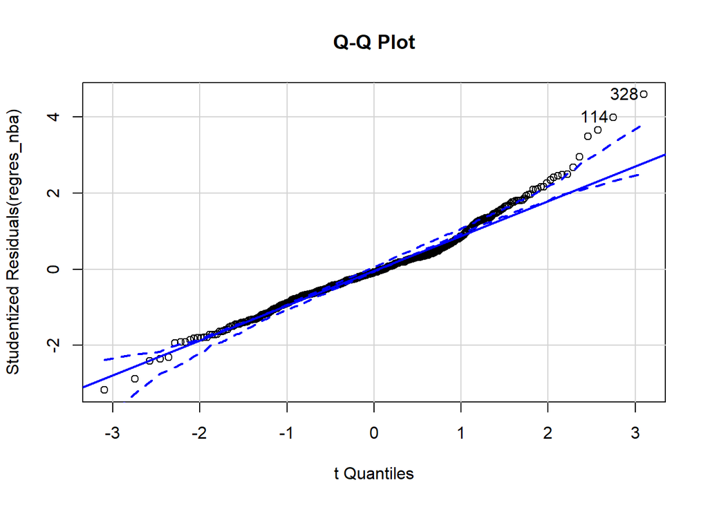

```
## [1] 114 328
```

Se representa graficamente la distribución de los errores:

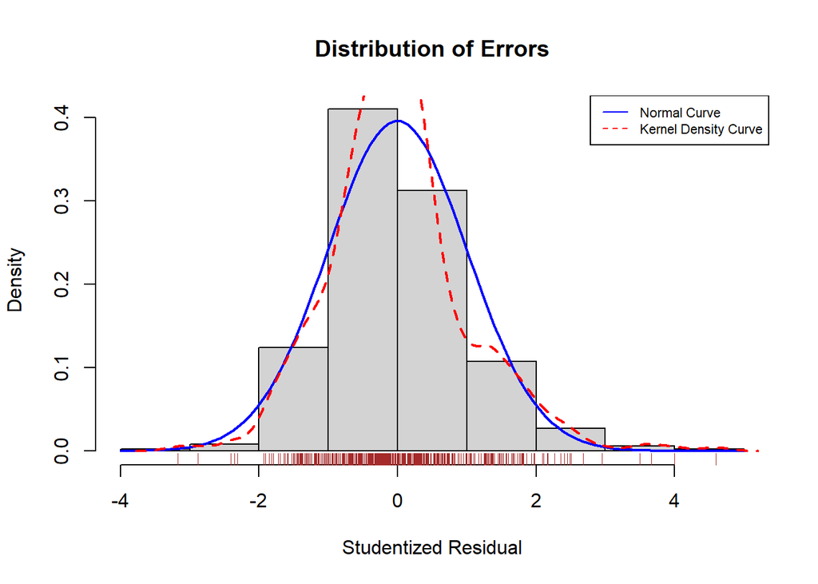

#### Jarque Bera - contraste de normalidad de los residuos.

El jaeque-Bera test nos informa sobre la normalidad de los errores. Para ello realiza un teste con as siguientes hipótesis: H0 = los residuos sigue una distribución normal H1 = sigue otro tipo de distribución.

```
##
## Title:
##  Jarque - Bera Normality Test
##
## Test Results:
##   PARAMETER:
##     Sample Size: 483
##   STATISTIC:
##     LM: 84.529
##     ALM: 87.406
##   P VALUE:
##     Asymptotic: < 2.2e-16
##
## Description:
##  Wed Oct 28 19:24:13 2020 by user: Beatriz
```

Los resultado del P-Valor nos indican que rechazamos la hipóteisis nula, por lo que la distribución de los errores no sigue una distribución normal

#### Shapiro-Wilk - contraste de normalidad.

El Shapiro-Wilk test nos informa sobre la normalidad de los errores. Para ello realiza un teste con as siguientes hipótesis: H0 = los residuos sigue una distribución normal H1 = sigue otro tipo de distribución.

```
##
##  Shapiro-Wilk normality test
##
## data:  vResid
## W = 0.97066, p-value = 2.981e-08
```

Como el P-Valor<0.05 nos indica que se rechaza la hipóteisis nula, por lo que la distribución de los errores no sigue una distribución normal

Tras estas comprobaciones y representacions se determina que no se cumple el supuesto de normalidad de los residuos para este modelo.

### Validación Global

```
##
## Call:
## lm(formula = Salary ~ . - Player - NBA_Country - Tm, data = nba_data)
##
## Residuals:
##       Min        1Q    Median        3Q       Max
## -15344434  -2975002   -390994   2102049  21682686
##
## Coefficients:
##                 Estimate Std. Error t value Pr(>|t|)
## (Intercept)     -2250339    4899140  -0.459    0.646
## NBA_DraftNumber   -60481      12755  -4.742 2.83e-06 ***
## Age               516821      56511   9.146  < 2e-16 ***
## G                -154411      24983  -6.181 1.41e-09 ***
## MP                  5657       1083   5.224 2.67e-07 ***
## PER              -355059     280566  -1.266    0.206
## TS.             -2162767    5149052  -0.420    0.675
## X3PAr           -3458209    2357905  -1.467    0.143
## FTr              -158470     886960  -0.179    0.858
## ORB.            -1055234     902929  -1.169    0.243
## DRB.             -855005     893502  -0.957    0.339
## TRB.             2006676    1788697   1.122    0.263
## AST.              -19606      47542  -0.412    0.680
## STL.             -196551     421995  -0.466    0.642
## BLK.              110238     318223   0.346    0.729
## TOV.                4208      52692   0.080    0.936
## USG.              169431     104692   1.618    0.106
## OWS             -1271685    4493110  -0.283    0.777
## DWS             -1735775    4518854  -0.384    0.701
## WS               1827796    4498896   0.406    0.685
## WS.48            1914677   11797052   0.162    0.871
## OBPM             1878971    4744860   0.396    0.692
## DBPM             1438902    4660878   0.309    0.758
## BPM             -1295954    4678340  -0.277    0.782
## VORP              629465     633799   0.993    0.321
## ---
## Signif. codes:  0 '***' 0.001 '**' 0.01 '*' 0.05 '.' 0.1 ' ' 1
##
## Residual standard error: 5103000 on 458 degrees of freedom
##   (2 observations deleted due to missingness)
## Multiple R-squared:  0.5479, Adjusted R-squared:  0.5242
## F-statistic: 23.13 on 24 and 458 DF,  p-value: < 2.2e-16
##
##
## ASSESSMENT OF THE LINEAR MODEL ASSUMPTIONS
## USING THE GLOBAL TEST ON 4 DEGREES-OF-FREEDOM:
## Level of Significance =  0.05
##
## Call:
##  gvlma(x = regres_nba)
##
##                       Value   p-value                   Decision
## Global Stat        117.1719 0.000e+00 Assumptions NOT satisfied!
## Skewness            32.4118 1.247e-08 Assumptions NOT satisfied!
## Kurtosis            52.1172 5.228e-13 Assumptions NOT satisfied!
## Link Function       32.1027 1.462e-08 Assumptions NOT satisfied!
## Heteroscedasticity   0.5402 4.623e-01    Assumptions acceptable.
```

### Multicolinealidad

Estudia las correlaciones lineales entre las variables explicativas. Se determina por el Factor de inflación de varianza (VIF). Cuanto mayor es mayor multicolinealidad en una variable. En este caso determinamos una alta multicolinealidad si sqrt(vif(regres_nba)) > 2

```
## NBA_DraftNumber             Age               G              MP             PER
##        1.342520        1.079819        7.060934       14.225204      111.433074
##             TS.           X3PAr             FTr            ORB.            DRB.
##        6.194013        5.297330        1.263474      316.727002      681.928718
##            TRB.            AST.            STL.            BLK.            TOV.
##     1436.507667        3.458745        3.208711        5.312844        1.921716
##            USG.             OWS             DWS              WS           WS.48
##        6.886673     1325.576479      404.022191     2679.552208       68.627896
##            OBPM            DBPM             BPM            VORP
##    10537.222382     2304.619311    13004.117445       11.572767
```

```
## NBA_DraftNumber             Age               G              MP             PER
##           FALSE           FALSE            TRUE            TRUE            TRUE
##             TS.           X3PAr             FTr            ORB.            DRB.
##            TRUE            TRUE           FALSE            TRUE            TRUE
##            TRB.            AST.            STL.            BLK.            TOV.
##            TRUE           FALSE           FALSE            TRUE           FALSE
##            USG.             OWS             DWS              WS           WS.48
##            TRUE            TRUE            TRUE            TRUE            TRUE
##            OBPM            DBPM             BPM            VORP
##            TRUE            TRUE            TRUE            TRUE
```

Hay bastantes variables que muestran multicolinealidad.

### Outliers

Se comprueban graficamnete los valores atípicos para decidir si se eliminan o se cambian por la media o la mediana.

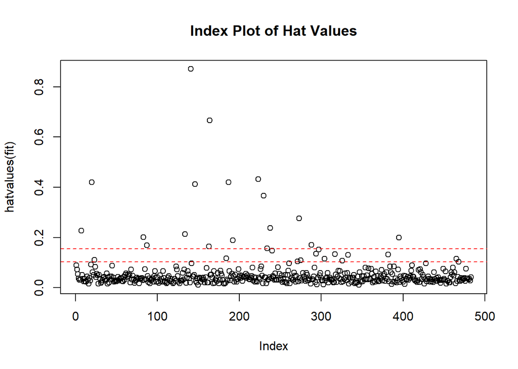

```
## integer(0)
```

Este gráfico muestra que hay valores que se encuentran alejados del resto de valores. Estos son los valores atípicos.

### Valores influyentes

#### Influenceplot.

Se realiza el plot de influencia para ver que valores están afectado más a la regresión. Lo realizamos sobre el conjunto de las observaciones de la muestra y según los valores de la regresión que contiene todas las observaciones y todas las variables numéricas.

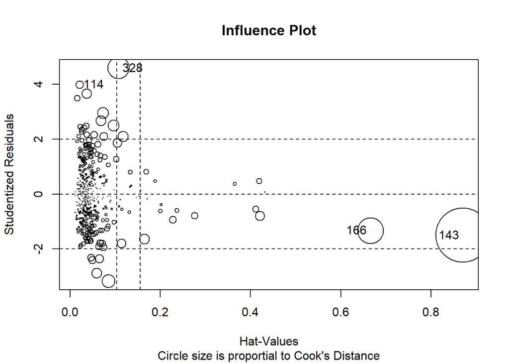

```
##       StudRes        Hat      CookD
## 114  3.999924 0.02088586 0.01321866
## 143 -1.499158 0.87069022 0.60367897
## 166 -1.326126 0.66551439 0.13973034
## 328  4.595907 0.10778593 0.09777366
```

```r
nba_data_clean <- nba_data[-c(166,143,328,114),]
nba_data_clean = na.omit(nba_data_clean)
```

#### Cook´s distance

Con este gráfico podemos confirmar los datos del influence plot, Observamos que los valores que más influyen se identifican con los resultado del plot anterior

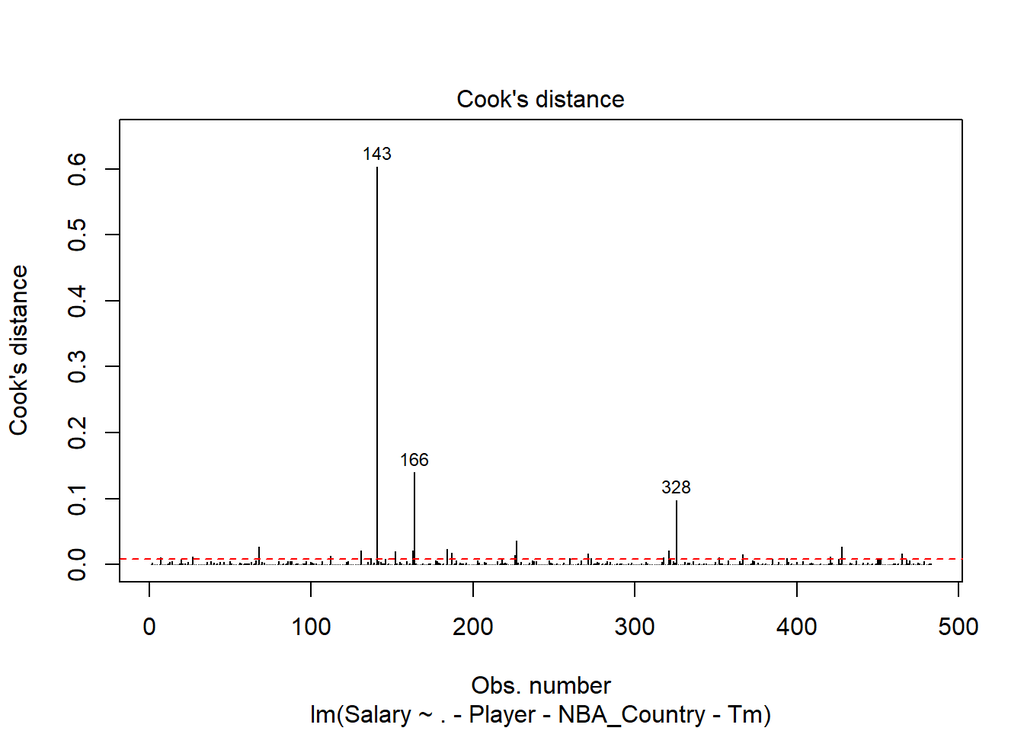

### Regresión Lineal Múltiple con las observaciones seleccionadas:

Realizamos la regresión para los datos de la muestra en la que se han quitado los valores influyentes. Esta parate de la muestra la hemos llamado nba_data_clean.

```
##
## Call:
## lm(formula = Salary ~ . - Player - NBA_Country - Tm, data = nba_data_clean)
##
## Residuals:
##       Min        1Q    Median        3Q       Max
## -15153543  -2944121   -287113   2124999  18039648
##
## Coefficients:
##                 Estimate Std. Error t value Pr(>|t|)
## (Intercept)        92448    4755378   0.019    0.984
## NBA_DraftNumber   -58117      12383  -4.693 3.56e-06 ***
## Age               499908      54584   9.159  < 2e-16 ***
## G                -142410      24125  -5.903 7.00e-09 ***
## MP                  5259       1072   4.905 1.30e-06 ***
## PER              -387651     290434  -1.335    0.183
## TS.             -6831755    5376818  -1.271    0.205
## X3PAr           -3612183    2291587  -1.576    0.116
## FTr              1300043    1544045   0.842    0.400
## ORB.             -738501     875380  -0.844    0.399
## DRB.             -582551     865035  -0.673    0.501
## TRB.             1416261    1733686   0.817    0.414
## AST.              -38926      46863  -0.831    0.407
## STL.             -191541     413312  -0.463    0.643
## BLK.              138668     309949   0.447    0.655
## TOV.               50656      56598   0.895    0.371
## USG.              185990     114311   1.627    0.104
## OWS             -1590887    4327035  -0.368    0.713
## DWS             -1898166    4350749  -0.436    0.663
## WS               2184877    4333611   0.504    0.614
## WS.48            2265687   15224153   0.149    0.882
## OBPM             2585991    4572637   0.566    0.572
## DBPM             1930456    4487728   0.430    0.667
## BPM             -1797500    4506226  -0.399    0.690
## VORP              442904     625664   0.708    0.479
## ---
## Signif. codes:  0 '***' 0.001 '**' 0.01 '*' 0.05 '.' 0.1 ' ' 1
##
## Residual standard error: 4911000 on 454 degrees of freedom
## Multiple R-squared:  0.5648, Adjusted R-squared:  0.5418
## F-statistic: 24.55 on 24 and 454 DF,  p-value: < 2.2e-16
```

En este caso hay cuatro variables significativas para un α = 0.05. Aunque esto no tiene por qué tener relación con las variables usasadas en el modelo predictivo.

## Selección de variables

En este caso se utiliza el modelo AIC mixto. Estudia la información de los errores en la varianza, queremos que sea la menor posible. Por lo tanto, a menor AIC mejor modelo predictivo.

Finalmente indica cuales son las varibles que mejor funcionan en un modelo predictivo usando los datos en los que hemos eliminado los valores más influyentes.

```
## Start:  AIC=14784.16
## Salary ~ (Player + NBA_Country + NBA_DraftNumber + Age + Tm +
##     G + MP + PER + TS. + X3PAr + FTr + ORB. + DRB. + TRB. + AST. +
##     STL. + BLK. + TOV. + USG. + OWS + DWS + WS + WS.48 + OBPM +
##     DBPM + BPM + VORP) - Player - NBA_Country - Tm
##
##                   Df  Sum of Sq        RSS   AIC
## - WS.48            1 5.3410e+11 1.0949e+16 14782
## - OWS              1 3.2598e+12 1.0951e+16 14782
## - BPM              1 3.8371e+12 1.0952e+16 14782
## - DBPM             1 4.4623e+12 1.0953e+16 14782
## - DWS              1 4.5902e+12 1.0953e+16 14782
## - BLK.             1 4.8268e+12 1.0953e+16 14782
## - STL.             1 5.1791e+12 1.0953e+16 14782
## - WS               1 6.1297e+12 1.0954e+16 14782
## - OBPM             1 7.7127e+12 1.0956e+16 14782
## - DRB.             1 1.0937e+13 1.0959e+16 14783
## - VORP             1 1.2084e+13 1.0960e+16 14783
## - TRB.             1 1.6093e+13 1.0964e+16 14783
## - AST.             1 1.6638e+13 1.0965e+16 14783
## - FTr              1 1.7096e+13 1.0965e+16 14783
## - ORB.             1 1.7163e+13 1.0965e+16 14783
## - TOV.             1 1.9317e+13 1.0968e+16 14783
## - TS.              1 3.8932e+13 1.0987e+16 14784
## - PER              1 4.2961e+13 1.0991e+16 14784
## <none>                          1.0948e+16 14784
## - X3PAr            1 5.9918e+13 1.1008e+16 14785
## - USG.             1 6.3840e+13 1.1012e+16 14785
## - NBA_DraftNumber  1 5.3118e+14 1.1479e+16 14805
## - MP               1 5.8020e+14 1.1528e+16 14807
## - G                1 8.4027e+14 1.1788e+16 14818
## - Age              1 2.0227e+15 1.2971e+16 14863
##
## Step:  AIC=14782.18
## Salary ~ NBA_DraftNumber + Age + G + MP + PER + TS. + X3PAr +
##     FTr + ORB. + DRB. + TRB. + AST. + STL. + BLK. + TOV. + USG. +
##     OWS + DWS + WS + OBPM + DBPM + BPM + VORP
##
##                   Df  Sum of Sq        RSS   AIC
## - OWS              1 3.3086e+12 1.0952e+16 14780
```

[output cut: 387 more lines]

```
## - X3PAr            1 8.5215e+13 1.1200e+16 14767
## + WS.48            1 2.7036e+12 1.1112e+16 14767
## + OWS              1 1.9627e+12 1.1112e+16 14767
## + DWS              1 1.2482e+12 1.1113e+16 14767
## + STL.             1 8.2900e+10 1.1114e+16 14767
## + AST.             1 5.2682e+09 1.1114e+16 14767
## - PER              1 1.2203e+14 1.1236e+16 14769
## - USG.             1 1.4016e+14 1.1254e+16 14769
## - OBPM             1 1.4708e+14 1.1261e+16 14770
## - TRB.             1 2.0201e+14 1.1316e+16 14772
## - NBA_DraftNumber  1 5.7920e+14 1.1694e+16 14788
## - WS               1 6.3229e+14 1.1747e+16 14790
## - MP               1 9.0795e+14 1.2022e+16 14801
## - G                1 1.2203e+15 1.2335e+16 14813
## - Age              1 2.0405e+15 1.3155e+16 14844
```

```
##
## Call:
## lm(formula = Salary ~ NBA_DraftNumber + Age + G + MP + PER +
##     X3PAr + ORB. + TRB. + USG. + WS + OBPM, data = nba_data_clean)
##
## Coefficients:
##     (Intercept)  NBA_DraftNumber              Age                G
##        -3517221           -59208           492330          -151180
##              MP              PER            X3PAr             ORB.
##            5071          -321215         -3137159          -161217
##            TRB.             USG.               WS             OBPM
##          296917           131530           834590           584523
```

El modelo con menor AIC (información de los errores en la varianza) es el siguiente: lm(formula = Salary ~ NBA_DraftNumber + Age + G + MP + PER + X3PAr + ORB. + TRB. + USG. + WS + OBPM, data = nba_data_clean).

Definimos este modelo como modelo_AIC.

- Multicolinealidad Para asegurarnos que es un buen modelo predictivo, se realiza un examen de la multicolinealidad para el modelo propuesto por el criterio AIC.

Establecemos que puede generar un problema en el modelo de predicción aquellas variables que sqrt(vif(modelo_AIC)) > 3.

```
## NBA_DraftNumber             Age               G              MP             PER
##        1.283487        1.041283        5.387402        8.835985       18.757561
##           X3PAr            ORB.            TRB.            USG.              WS
##        2.798151        3.431809        5.018736        1.926710        3.779480
##            OBPM
##       16.855287
```

```
## NBA_DraftNumber             Age               G              MP             PER
##           FALSE           FALSE           FALSE           FALSE            TRUE
##           X3PAr            ORB.            TRB.            USG.              WS
##           FALSE           FALSE           FALSE           FALSE           FALSE
##            OBPM
##            TRUE
```

Siguiendo este criterio vamos a prescindir de las siguientes variables: PER y OBPM.

Definimos un nuevo modelo que contiene las variables propuestas por el criterio AIC y eliminando aquellas que muestras alta multicolinealidad.

Definimos el modelo definitivo: modelo_def = lm(formula = Salary ~ NBA_DraftNumber + Age + G + MP + X3PAr + ORB. + TRB. + USG. + WS , data = nba_data_clean

```
##
## Call:
## lm(formula = Salary ~ NBA_DraftNumber + Age + G + MP + X3PAr +
##     ORB. + TRB. + USG. + WS, data = nba_data_clean)
##
## Residuals:
##       Min        1Q    Median        3Q       Max
## -15154024  -2987547   -227321   2210144  18636703
##
## Coefficients:
##                   Estimate Std. Error t value Pr(>|t|)
## (Intercept)     -7777440.2  2089494.8  -3.722 0.000222 ***
## NBA_DraftNumber   -62695.3    11903.1  -5.267 2.12e-07 ***
## Age               501969.1    53272.1   9.423  < 2e-16 ***
## G                -145024.5    20918.4  -6.933 1.37e-11 ***
## MP                  5240.6      814.6   6.433 3.08e-10 ***
## X3PAr            -548169.1  1266766.1  -0.433 0.665409
## ORB.             -113969.9    88143.0  -1.293 0.196644
## TRB.              155292.5    82890.1   1.873 0.061624 .
## USG.               66214.1    45459.0   1.457 0.145905
## WS                887495.8   151709.6   5.850 9.23e-09 ***
## ---
## Signif. codes:  0 '***' 0.001 '**' 0.01 '*' 0.05 '.' 0.1 ' ' 1
##
## Residual standard error: 4901000 on 469 degrees of freedom
## Multiple R-squared:  0.5522, Adjusted R-squared:  0.5436
## F-statistic: 64.27 on 9 and 469 DF,  p-value: < 2.2e-16
```

En este caso tenemos 6 variables signitficativas para un α = 0.05 y 7 para un α = 0.1

### Muestra aleatotria

Se crea una muestra aleatoria del total de nba_data_clean que será la que usemos para evaluar las predicciones de los salarios con el modelo anterioremete definido. En este caso se seleccionan 10 jugadores para la muestra aleatoria.

```
## [1] 479
```

```
##  [1] "Glenn Robinson" "Mario Hezonja"  "Nikola Mirotic" "Chris Paul"
##  [5] "Alex Abrines"   "Jahlil Okafor"  "Jeremy Evans"   "Allen Crabbe"
##  [9] "Lou Williams"   "Ivan Rabb"
```

Estos son los nombre de los jugadores de la muestra aleatoria con la que vamos a evaluar nuestro modelo predictivo

### Modelo predictivo - Prediccón de Salarios

Estos son los salarios para cada jugador de la muestra aleatoria según sus caraterísticas y el modelo definido.

```
##  [1]  1661405.9  4818851.1  9331492.0 20357967.5   386734.8  4043864.0
##  [7]  4059668.6  7342227.4 15390172.6   811828.0
```

Estos son los salarios para cada jugador de la muestra aleatoria según sus caraterísticas.

Ahora comparamos los salarios estimados con los salarios reales. Mostarmos la diferencia en $

```
##  [1]  -137100.9  -740531.1  3168508.0  4241527.5  5338265.2   951256.0
##  [7] -3955609.6 11990272.6 -8390172.6   138172.0
```